# Fitting a neural ODE with handmade packages

Author

David Métivier

Published

October 12, 2026

Neural ODE — putting the four packages together

du/dt = NN(u), NN a small neural network whose weights we fit to data.

Four packages, written independently this morning, meet here for the first time. None of them depends on any other.

FrejusJuliaAD0 derivatives (dual numbers) FrejusJuliaODE0 time integration FrejusJuliaNeuralNetworks0 the model FrejusJuliaOptimization0 the optimiser

```julia
cd(@__DIR__)  # so that `using` finds the packages in this folder
import Pkg; Pkg.activate(".")  # so that `using` finds the packages in this folder
using FrejusJuliaAD0              # jacobian, gradient
using FrejusJuliaODE0           # solve_ode, euler_step, rk4
using FrejusJuliaNeuralNetworks0  # Dense, Chain, parameters, rebuild
using FrejusJuliaOptimization0          # gauss_newton, gradient_descent

using Printf
using Random
```

```
  Activating project at `C:\Users\metivier\Dropbox\PC (2)\Documents\cours\2026_formation_Julia\pkg_creation\neural_ode`
```

# The data

A damped rotation, du/dt = A u. This is the “true physics”, which the network is not told about: all it will ever see is `nsave` points of one trajectory.

```julia
# ===========================================================================

const A = [-0.1 2.0; -2.0 -0.1]     # slow decay + rotation => a spiral
const u0 = [2.0, 0.0]
const tspan = (0.0, 3.5)

const nsave = 60                    # number of observations
const substeps = 4                  # integration steps between two observations
const nsteps = (nsave - 1) * substeps

true_rhs(u, p, t) = p * u
```

```
true_rhs (generic function with 1 method)
```

RK4 for the data (order 4): we want the observations to be essentially exact.

```julia
const truth = rk4(true_rhs, u0, A, tspan, nsteps)
const t_data = truth.t[1:substeps:end]
const data = truth.u[1:substeps:end]

@printf("Data: %d observations of a 2-D state on t in [%.1f, %.1f]\n", length(data), tspan[1], tspan[2])
```

```
Data: 60 observations of a 2-D state on t in [0.0, 3.5]
```

# The model

Replace the unknown right-hand side by a neural network:

```
du/dt = NN(u)
```

8 hidden units is enough. `identity` on the output layer, because a velocity is not bounded in [-1, 1].

```julia
Random.seed!(42)
const model = Chain(Dense(2 => 8, tanh), Dense(8 => 2, identity))
const theta0 = parameters(model)

@printf("Model: %s  (%d parameters)\n", repr(model), length(theta0))
```

```
Model: Chain(Dense(2 => 8, tanh), Dense(8 => 2, identity))  (42 parameters)
```

# From “a neural network” to “a function of a vector”

The optimiser knows nothing about layers; it minimises over R^42. `rebuild` is the translation, and these three functions are the whole bridge between the model and the solver.

```julia
"Trajectory predicted by the parameters `theta`, sampled at the observation times."
function predict(theta, initial = u0)
    net = rebuild(model, theta)                              # vector  -> network
    rhs(u, p, t) = net(u)                                    # network -> ODE
    sol = solve_ode(rhs, initial, theta, tspan, nsteps; step = euler_step)
   return sol.u[1:substeps:end]
end
```

```
predict (generic function with 2 methods)
```

All prediction errors, stacked into one long vector.

```julia
residuals(theta) = reduce(vcat, predict(theta) .- data)
```

```
residuals (generic function with 1 method)
```

Sum of squares — the quantity we actually minimise.

```julia
loss(theta) = sum(abs2, residuals(theta))

@printf("Loss before training: %.4e\n", loss(theta0))
```

```
Loss before training: 2.4959e+02
```

# The derivatives

THIS IS THE POINT OF THE WHOLE EXERCISE.

`jacobian` pushes dual numbers into `residuals`. Those duals travel through `rebuild` and the forward pass (neural network package), then through every Euler step (ODE package), and come back out carrying the derivatives.

Neither of those two packages has ever heard of a dual number. They work because they were written generically: no `Float64`, no array allocated with an assumed element type. Multiple dispatch does the rest.

```julia
jac(theta) = jacobian(residuals, theta)
```

```
jac (generic function with 1 method)
```

Sanity check: compare one column against a finite difference.

```julia
let h = 1.0e-6, k = 5
    theta_shift = copy(theta0)
    theta_shift[k] += h
    finite_difference = (residuals(theta_shift) .- residuals(theta0)) ./ h
    @printf("AD vs finite differences on column %d: max difference %.2e\n",
        k, maximum(abs, jac(theta0)[:, k] .- finite_difference))
end
```

```
AD vs finite differences on column 5: max difference 2.83e-06
```

# Training

## Gauss-Newton

Fitting a model to data by least squares is exactly what Gauss-Newton is for: it only ever needs the Jacobian of the residuals, never a Hessian.

```julia
elapsed = @elapsed result = gauss_newton(residuals, jac, theta0; maxiter = 100)

@printf("\nGauss-Newton: loss %.4e -> %.4e in %d iterations (%.2f s)\n",
    result.history[1], result.history[end], result.iterations, elapsed)

println("\n  iteration      loss")
for k in (1, 3, 6, 11, 21, 51, length(result.history))
    @printf("  %9d   %.4e\n", k - 1, result.history[k])
end
println("  (the loss is flat over the first iterations: Levenberg-Marquardt is")
println("   rejecting steps and raising lambda until the linear model is trusted)")
```

```
Gauss-Newton: loss 2.4959e+02 -> 8.3620e-05 in 100 iterations (0.55 s)

  iteration      loss
          0   2.4959e+02
          2   2.4959e+02
          5   2.4959e+02
         10   5.2948e+01
         20   7.3490e-02
         50   2.2452e-04
        100   8.3620e-05
  (the loss is flat over the first iterations: Levenberg-Marquardt is
   rejecting steps and raising lambda until the linear model is trusted)
```

## The baseline: gradient descent

Same problem, same derivatives, with a simple gradient descent. It is much slower than Gauss-Newton, because it does not use the Jacobian to linearise the problem. It is included here for comparison.

```julia
grad(theta) = gradient(loss, theta)

elapsed_gd = @elapsed descent = gradient_descent(loss, grad, theta0; η = 1.0e-3, maxiter = 500)

@printf("\nGradient descent: loss %.4e -> %.4e in %d iterations (%.2f s)\n",
    descent.history[1], descent.history[end], descent.iterations, elapsed_gd)
@printf("Gauss-Newton reached %.4e, i.e. about %.0e times lower.\n",
    result.history[end], descent.history[end] / result.history[end])
```

```
Gradient descent: loss 2.4959e+02 -> 1.9736e+01 in 500 iterations (2.17 s)
Gauss-Newton reached 8.3620e-05, i.e. about 2e+05 times lower.
```

# How good is the fit?

```
      t        data u1     model u1       data u2     model u2
   0.00      2.00000     2.00000       0.00000     0.00000
   0.36      1.46134     1.46138      -1.26081    -1.26212
   0.71      0.27294     0.27385      -1.84247    -1.84169
   1.07     -0.96207    -0.96241      -1.51830    -1.51877
   1.42     -1.66010    -1.66137      -0.50288    -0.50295
   1.78     -1.53000    -1.52931       0.67909     0.67938
   2.14     -0.68982    -0.69042       1.46072     1.46050
   2.49      0.41681     0.41699       1.50217     1.50206
   2.85      1.25152     1.25200       0.83483     0.83505
   3.20      1.44073     1.44114      -0.17898    -0.17944

Largest error along the trajectory: 2.89e-03
[ Info: wrote C:\Users\metivier\Dropbox\PC (2)\Documents\cours\2026_formation_Julia\pkg_creation\neural_ode\neural_ode.png
```

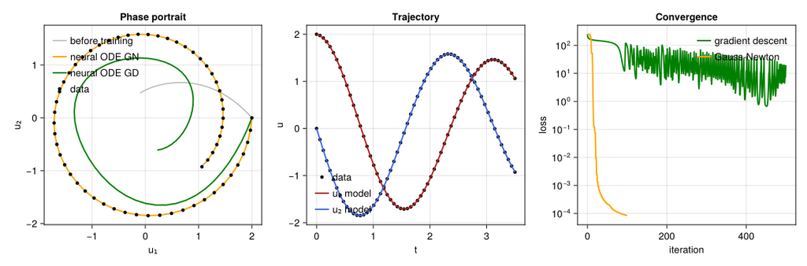

```julia
prediction = predict(result.x)
prediction_gd = predict(descent.x)

println("\n      t        data u1     model u1       data u2     model u2")
for k in 1:6:length(data)
    @printf("  %5.2f   %10.5f  %10.5f    %10.5f  %10.5f\n",
        t_data[k], data[k][1], prediction[k][1], data[k][2], prediction[k][2])
end

@printf("\nLargest error along the trajectory: %.2e\n",
    maximum(maximum(abs, p .- d) for (p, d) in zip(prediction, data)))

include("plot_neural_ode.jl")  # make the figure
```

*This page was generated using Literate.jl.*